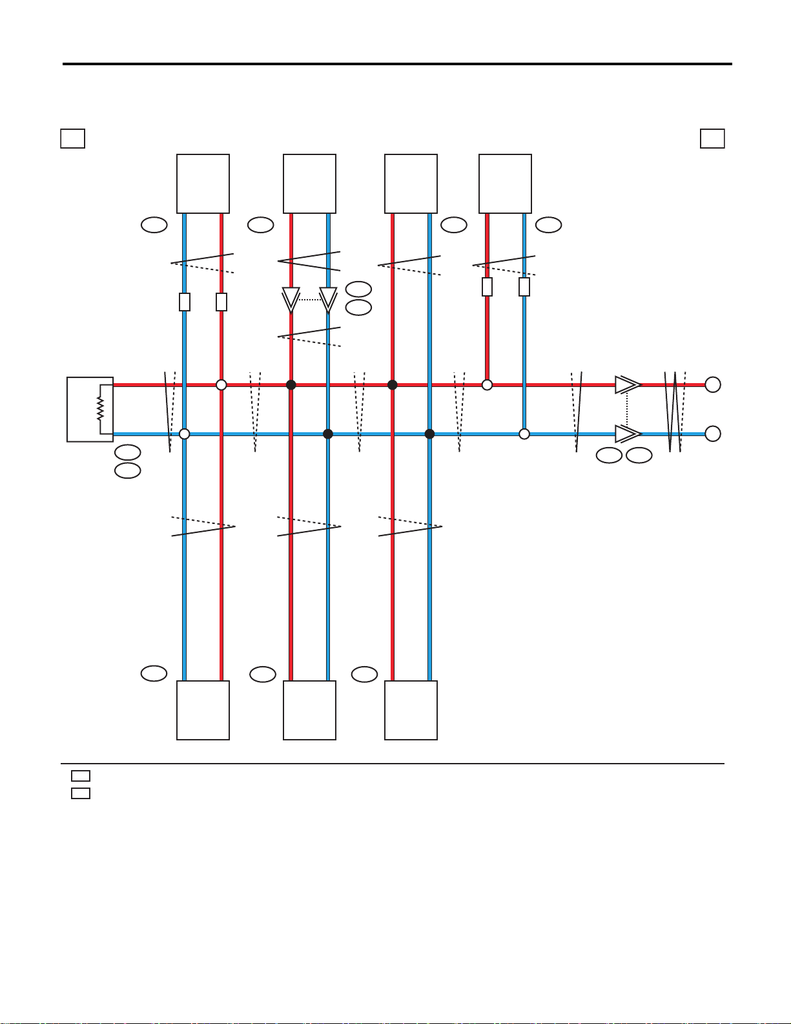

CAN Communication System

WIRING SYSTEM

10.CAN Communication System

A: WIRING DIAGRAM

a a

L

R

4

3

ECM B134A:

B136C:

L

R

L

R

L

R

B551 i229

A

B

A13

A22

AB6

AIRBAG CM

R

L

R

L

R

L

3

2

B231

R

L

A7

A6

B450A:

L

R

STEERING

ANGLE SENSOR

POWER

STEERING CM

R

L

43

44

B54

A:

B556

AB65

WE

WE

IMPACT SENSOR TCM

6

5

L

R

B367

: WITH ELECTRIC POWER STEERING

: ENGINE TYPE EJ

WE

REMOTE

ENGINE START CM

2

1

R

L

B180

EJ

EJ

6

7

1

2

2

18

B380

R

L

DCCD CM

EJ

1

2

: WITHOUT PUSH BUTTON START : 1

WITH PUSH BUTTON START : 2

3

: ENGINE TYPE FA : A10

ENGINE TYPE EJ : C17

4

: ENGINE TYPE FA : A9

ENGINE TYPE EJ : C28

: WITHOUT PUSH BUTTON START : 2

WITH PUSH BUTTON START : 3

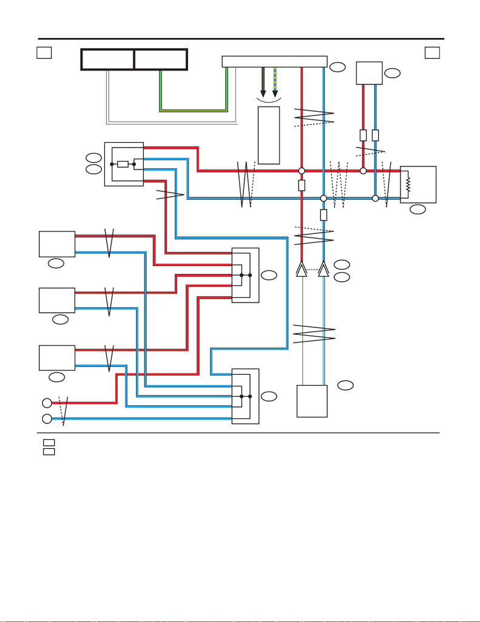

WI-111

CAN Communication System

WIRING SYSTEM

WI-44311

b b

W

16W

8G/Y

5

DATA LINK CONNECTOR

G/Y

4B/Y

6R

14

REF. TO ENGINE

ELECTRICAL SYSTEM

[1g] [2g] [3f] [4f]

B40

B310

VDC CM

R

L

L

L

R

R

B28

C27

L

C35

B20

BODY

INTEGRATED UNIT

B281B:

i84C:

W

SB

C14

C15

B574C:

B28

B23

WP

WP

R

L

W

SB

WP

: WITH PUSH BUTTON START

AL

: WITH AUTO HEADLIGHT BEAM LEVELER

1

1

i233

J/C

i232

KEYLESS

ACCESS CM

MB-27

M/B FUSE NO. 13

(B)

FB-32

F/B FUSE NO. 4

(IG)

I/F

B

1

1

1

J/C

1

2

1

1

1

1

A

R

R

R

L

R

R

R

L

L

L

L

L

35

36

7

6

COMBINATION

METER

R

L

20

19

i88

R

L

33

32

i10

MFD

A6

A5

i122

R

L

A:

A/C CONTROL

PANEL

B150

23

24

R

L

AUTO HEADLIGHT

BEAM LEVELER CM

AL

AL

1

: TERMINAL No. OPTIONAL ARRANGEMENT

2

: ENGINE TYPE FA : B/R

ENGINE TYPE EJ : B/W

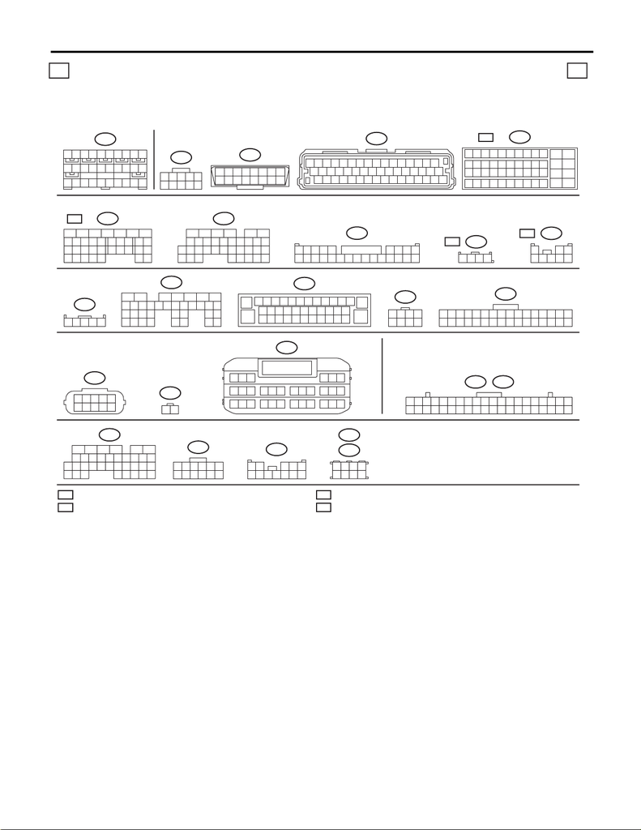

WI-112

CAN Communication System

WIRING SYSTEM

:

:

WI-44312

c c

B281B:

5672134

29

10 11 12 13 14 15

2524

16

30

98

17 18 19

20

28

21 22 23

3231

26 27

33 34 35

i229

12 345

6789

10 11 12

i233

i232

78

5

6

34

21

1234567

8

9

10

11 12 13 14

15 16 17 18 19 20

21 22 23 24 25 26 27 28 29 30

AB6

(Y)

A:

B40

(B)

1

9

8

16

2

10

7

15

3

11

6

14

4

12

5

13

18

23

26

24

25

98

15

1413121110

17

16

1234567

B134

A:

10

11 12

23 24

35 36

47 48

3

5

6

7894

12

45

21

2219 2017 1815 1613 14

33

3431 3229 3027 2825 26

(BR)

B134

A:

67893412 5

B150

B231

5341

2

B310

23456789

1

10 11 12 13

14

15

26

16 17 18 19 20 21 22 23 24 25

27 28 29 30 31 32 33 34 35 36 37

38

B367

1234

5678

A:

(B)

B450

9

10

78

5

6

34

2

1

i10 i88

11 12

9

10

7856341

2

15 1613 14 19

18

20

21 22 23 24 26

25

27 28 29 30 31 32 33 34 35 36 37 38 39 40

17

i84C:

19

18

21

20

2322 24 25 26

17

1

23

4

56

27

28 29 30

31 32 33 34 35

798

151413121110 16

11 12

9

10

78

65341

2

i122

(B)

A:

B380

896745231

15 1613 1411 1210

B556

21

B136C:

19

18

21

20

2322 24 25 26

17

1

23

4

56

27

28 29 30

31 32 33 34 35

798

151413121110 16

(B)

B54

123456789

10 11 12 13 14 15 16

17 18 19 20 21 22 23 24 25 26 27 28 29 30 31 32

33 34 35 36 37 38 39 40 41 42 43 44 45 46 47 48

B23

10

12345

6789

OP

WP

B574C:

19 20 21 22 23 24 25 26 27 28 29 30

789

10 11 12 13 14 15 16 17 18

123 456

B180

341

2

OP

:

B180

123

45678

WP

:

EJ

FA

FA

EJ

LIST OF CONNECTORS

: WITHOUT PUSH BUTTON START

: WITH PUSH BUTTON START

: ENGINE TYPE EJ

: ENGINE TYPE FA